# **Day 2: Data tidying and analysis**

### **Getting the data into `phyloseq`**

**Step 13. Creating `phyloseq` input files**

Choose `picked.fasta`, `picked.count_table` and `sequences-taxonomy-assignment.txt`. Next, tun the tool `Generate input files for phyloseq` so that you select the correct data type (`16S, 18S or archaeal`) and set a dissimilarity threshold of 0.03% for OTU clustering.

```
Why are we using a threshold of 0.03%?
Can you think of examples where another threshold might be more appropriate?
```

**Step 14. Filling in the phenodata file**

The `Generate input files for phyloseq` tool produces a phenodata file (a file type in Chipster used for documenting sample groupings). Before proceeding with downstream analyses, let's take a moment to work on the phenodata. We'll imagine there are two columns with sample groupings that we're interested in: `chiptype` and `group`.

1. Select `phenodata-file.opti_mcc.shared`.

2. Next, fill in the `group` column: mark all the early samples (`D0-D9`) with `a`, and the late samples (`D141-D150`) with `b`.

The end result should look like this:

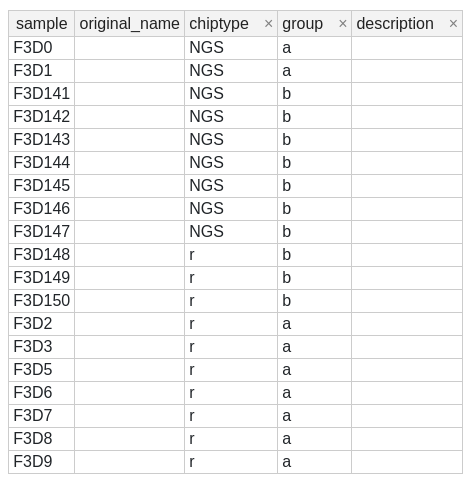

**Step 15. Producing a `phyloseq` object**

Finally! It's the moment we've been waiting for. 😄

Select the Mothur shared file and constaxonomy file. Run the `Convert Mothur files into phyloseq object` tool, noticing that here we need to specify the phenodata column including unique IDs for each community profile (in our case, the column `sample`).

This tool produces two files:

- a phyloseq object (stored as `ps.Rda`)
- a text summary of the imported object (`ps_imported.txt`).

```
Inspect the text summary a little closer.
What elements does the phyloseq object consist of?
```

### **Inspecting and tidying the data**

**Step 16. Sequence numbers, rarefaction curve and alpha diversity indices**

For this step, select the Rda file produced in **Step 15**. Try running the `Sequence numbers, rarefaction curve and alpha diversity estimates` tool. There are a couple of parameters to fill in - have a look at these in advance. Choose a phenodata variable to tabulate with the alpha diversity values and make sure you are telling the tool that we are working with raw data.

```
Can you already make some basic inferences about the data
based on the rarefaction curve and alpha diversity values?

Based on the rarefaction curve, what do you think might be
best - proceeding as is or rarefying the data to even depth?
```

Feel free to try the `Rarefy OTU data to even depth` tool using the same Rda file and re-running the `Sequence numbers...` tool using the resulting dataset (ps_rarefied.Rda). If doing this, remember that you need to specify in the `Sequence numbers...` tool that the data are rarefied to even depth.

**Step 17. Overview of taxon composition**

Let's move on using the non-rarefied data set. Selecting `ps.Rda`, run the `Overview of taxon composition` tool, selecting Class as the level of biological organisation.

```
How many OTUs corresponding to Clostridia are there in the data set?

Do you see any particular classes in the data set that you
think could be removed - if yes, why would you exclude them?
```

**Step 18. Data tidying**

There are quite a few data tidying tools. Let's go through them one by one!

Don't worry if you get lost at first, we're here to help. 👍

1. Again selecting `ps.Rda`, tidy the data set using the `Filter by taxonomic group` tool, choosing `Bacteria` as the group to retain. This helps ensure that we only keep those data that are classified as Bacteria at the domain level.
2. Using the resulting Rda file (`ps_bacteria.Rda`), also run the `Remove selected taxa` tool. You could use this tool to filter out any taxa that you shortlisted for removal in **Step 17**. Even if not, this tool can be used to remove any chloroplast or mitochondrial sequences in the data.

```
Why might you expect to see chloroplast or mitochondrial
sequences in a bacterial dataset - isn't that a little strange?
```

3. Selecting `ps_ind.Rda`, run the `Additional prevalence summaries` tool. This will produce both a prevalence plot (`ps_prevalence.pdf`) and a text summary (`ps_low.txt`). The plot has a prevalence threshold of 5% drawn as a default guess for prevalence filtering.

```
How many doubletons are there in the data set?
Do you have an advance idea about what the term "prevalence" refers to?
```

4. There are two further tools for data tidying:
- Remove OTUs with 0-2 occurrences
- Proportional prevalence filtering

Selecting `ps_ind.Rda`, run the former tool, making sure that both singletons and doubletons are removed.

```
Why would we want to remove singletons and doubletons from the data?

Can you think of situations where these should be kept as part of the dataset
(hint: we have already covered one such step earlier)?
```

### **Taking a closer look at patterns**

**Step 19. Stacked taxon composition bar plots**

At this point, we have many alternatives that depend on the study goals. Let's say that, in our case, the goal is to compare the overall community structure between different groups (with individual OTUs being of limited interest at this stage).

Nevertheless, first we probably want to visualise the data and compare the groups in more detail. After all, we don't want to blindly rely on statistical test output!

Select `ps_pruned.Rda` and run the `Transform OTU counts` tool, selecting `Relative abundances (%)` as the data treatment. We can use relative abundance data to produce bar plots.

This will produce a file called `ps_relabund.Rda`. Select it and run the `OTU relative abundance bar plots` tool, making sure that you have the `Sample` column selected in `Phenodata variable with sequencing sample IDs`. There are quite a few other parameters here that you can also modify. Feel free to choose any cut-off threshold for excluding lower-abundance OTUs, otherwise selecting the following options:

- Family as the level of biological organisation
- group as phenodata variable 1 for plot faceting

The result should look close to this (click on the thumbnail to expand the image):

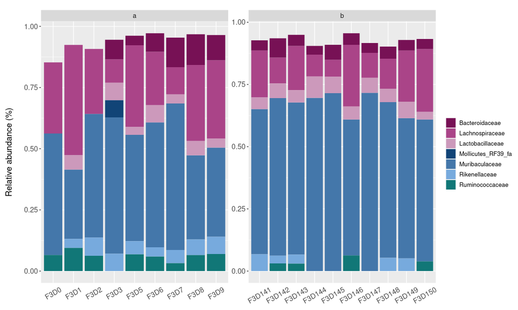

Great! But let's take a moment to think:

```
Based on the plot, what would you anticipate - are the groups likely to differ?
Can you think of another way to visualise the data?
```

**Step 20. Other ways to visualize the data**

Going back to `ps_pruned.Rda`, let's also visualise the data using a multivariate ordination. For this, first perform a CLR transformation using the `Transform OTU counts tool`.

```
Why might we want to use CLR transformation here, instead of % relative abundances?
```

Selecting the resulting file (`ps_clr.Rda`), run the `Distance matrices and ordinations` tool. Once again, one must specify a column in the phenodata with unique IDs for each sample (i.e. the `Sample` column). There are options for Euclidean and Bray-Curtis distances - choose Euclidean and for the ordination type, select nMDS. Also colour the ordination points by choosing `group` in `Phenodata variable for grouping ordination points by colour`.

In addition to nMDS, there is another ordination type (db-RDA), but let's focus on the nMDS for now.

```
Looking at the ordination, what features stand out?
Does it look like the difference between groups could be due to a "location effect",
"dispersion effect" or both?

What is the stress value of the nMDS (in ps_ordi.txt)?
Can you guess why this might be important?

What's the advantage of plotting individual sample names here?
```

As a bonus topic, you might also want to produce a db-RDA plot and consider this question:

```
When might you want to use db-RDA rather than nMDS?
```

### **Diving into statistics**

**Step 21. PERMANOVA**

Ok! We're ready to run some statistical tests now. Let's proceed with a permutational multivariate analysis of variance (PERMANOVA).

The `Distance matrices and ordinations` tool also produced a distance matrix (`ps_dist.Rda`) that we can use for statistical testing. Selecting it, run the `Global PERMANOVA for OTU abundance data` tool, selecting `Main effects and interactions` as the PERMANOVA formula and specifying `chiptype` as `Phenodata variable 1` and `group` as `Phenodata variable 2`.

```
What does the word "global" mean here?

How would you interpret the results (global_permanova.txt)?
Does the group variable (early versus late samples) explain, at least partly,
the differences in composition between groups?
```

Using `ps_dist.Rda`, also run the `PERMDISP for OTU abundance data` tool, selecting the same phenodata variables.

```
What does PERMDISP stand for? Why would we want to use it?

Comparing the output of this test with the global PERMANOVA results, can you confirm whether the PERMANOVA result is due to a location or dispersion effect?

Does the result match your earlier anticipations based on inspecting the ordination?
```

There are also post-hoc pairwise tests for further community comparisons. We do not need those for the present dataset, since we are only comparing two groups at a time.

**Step 22. DESeq2**

If we were interested in OTU-level differences between sample groups, we could turn to DESeq2 instead of PERMANOVA. For this, let's return to the untransformed dataset (`ps_pruned.Rda`).

Choosing that dataset and the `Transform OTU counts` tool, select `DEseq2 format conversion and variance-stabilizing transformation` as the data treatment. For the DESeq2 format conversion, we also need to specify a phenodata variable - for this, use `group`. We get two files as a result:

- `ps_vst.Rda`
- `deseq2.Rda`

Of these, `deseq2.Rda` can be used for DESeq2.

Selecting `deseq2.Rda`, run the `Differential OTU abundance analysis using DESeq2` tool, with the number of sample groups set to 2, the lower-level taxonomic grouping to Order and the higher-level grouping to Class.

Take a moment to inspect the results table (`deseq2_otutable.tsv`) and results plot (`deseq2_otuplot.pdf`).

```
Do some taxa seem more responsible for community-level differences than others?
```

Feel free to think about this bonus question, too:

```
How about the VST dataset - where might that come in handy?
```